# Soccer Simulator

Kenneth Day

6/23/2021

### **Explanation of Simulator**

The ultimate goal of the simulator is to determine how the possible outcomes from one match affect all of the other team’s end-of-season probabilities. The first thing the program does is input historical SPI rankings and match outcomes with predicted probabilities from the last 5 years (from [538](https://data.fivethirtyeight.com/#soccer-spi)). The program than isolates the matches for the specified league and splits it into training set and testing set. Using the match data, it creates different polynomial models of different orders to determine which one is best for modeling the SPI rankings to the match probabilities. It ouputs a graph like Figure 1, which shows the relative strength of the different-order regression models.

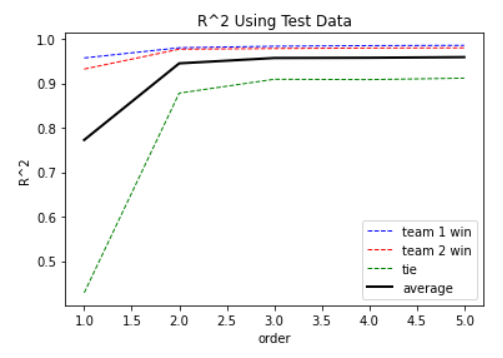

*Figure 1*

After it determines which order of polynomial to use, it performs ridge regression testing in order to determine the ideal alpha value. Figure 2 is an example of an alpha vs. R^2 graph it outputs.

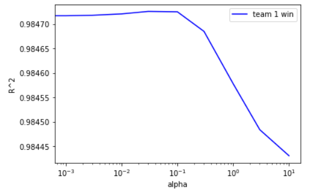

*Figure 2*

Next, it creates the final regression models for predicting the probability of win, loss, or draw based on SPI rankings. Using the test set, the accuracy of the model can be visualized like in Figure 3.

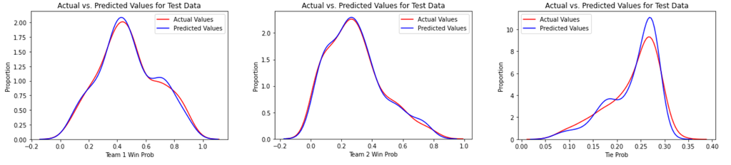

*Figure 3*

Having used machine learning to create the regression model, the season’s schedule and previous results are used to simulate the rest of the season and show the current and projected table. Figure 4 is an example from during the 19/20 Premier League season.

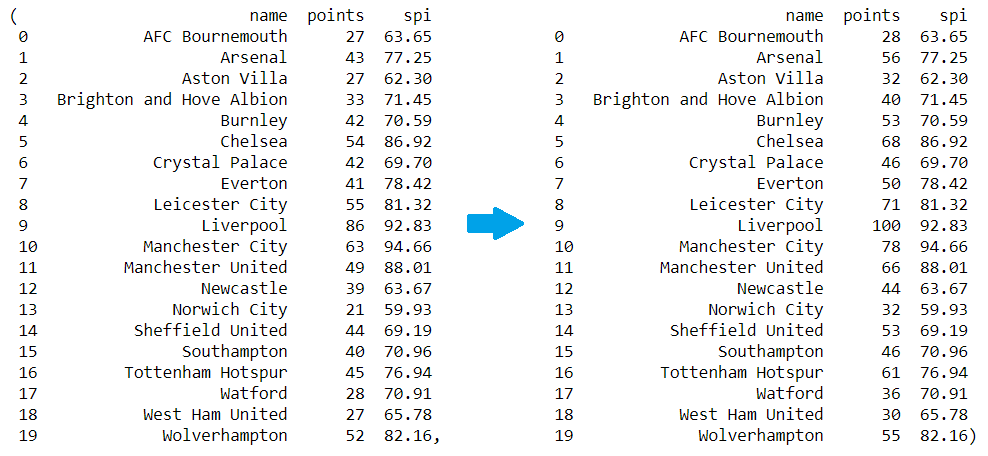

*Figure 4*

Building on that, the program outputs a table which shows what percent of outcomes each team gets in the n number of simulations performed (the default is 10,000 simulations). Figure 5 shows the table that corresponds to the Figure 4 simulation.

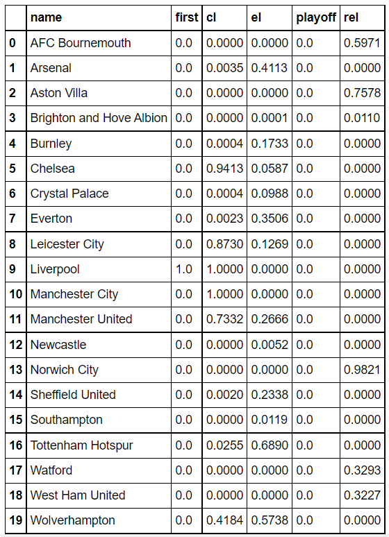

*Figure 5*

Finally, the user can select an upcoming match and the program will output all of the other teams’ end-of-season probabilities based on the three possible outcomes from selected match. An example of this is shown in Figure 6 below for a match between Crystal Palace and Burnley, where Figure 6 shows part of the output table. At the time, Arsenal was in direct competition with both teams for Europa League qualification, so you can see how Arsenal’s chances of qualifying for the Europa league change based on the outcome of the match. In the table, we can see the Arsenal has the highest probability of qualifying (43.6%) if the two teams draw (and only get one point each).

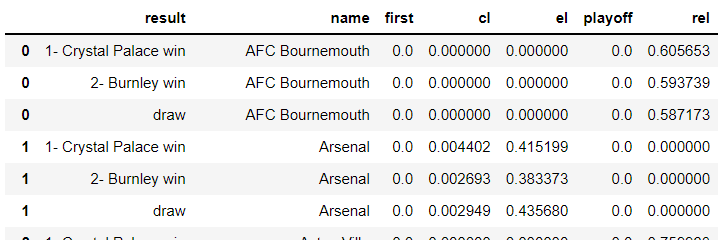

*Figure 6*